# Design of ordinal CRM

John Kirkpatrick and Wojciech Wójciak

Last run on 2023-06-27 by kirkpatj on rstudio-deployment-kirkpatj-p5571g-865bf846c6-jxvp6

# 1 The statistical model and theory about it.

The patient’s toxicity response is not binary (no DLT, DLT) but categorical (for example: no DLT, sub-DLT, DLT). Furthermore, multicategory toxicity responses are treated as ordinal due to their ordinal characteristics such as a monotone trend.

## 1.1 The model: Cumulative Link Models

These type of responses can be modeled using Generalized Linear Model (GLM), where the model is expressed in terms of the cumulative response probabilities. Hence, the name: Cumulative Link Model, or CLM. The CLM assumes the form:
$$h[p_{ij}] = h[P(Y_i \leq j)] = \alpha_j + \mathbf x_i^T \boldsymbol
\beta, \qquad j = 1, \ldots, c - 1; \, i \geq 1$$
where $c \in \{2, 3, \ldots \}$ denotes a number of toxicity categories on ordinal scale, and the components of the model are as follows:

1. $h$ - link function. The most common link functions are “logit” and “probit”, which result in Cumulative Logit Model and Cumulative Probit Model respectively.
2. $Y_i$ - random variable that represents the response outcome category for subject $i \geq 1$, i.e. $supp(Y_i) = \{1, 2, \ldots, c\},\, i \geq 1$. Probabilities $P(Y_i = j),\, j = 1, \ldots, c$, for $i \geq 1$, are called category probabilities, and the cumulative response probabilities for subject $i \geq 1$ are defined as
   $$p_{ij} = P(Y_i
   \leq j) = P(Y_i = 1) + \cdots + P(Y_i = j), \qquad j = 1, \ldots, c; ~ i
   \geq 1,$$
3. $\mathbf x_i$ - a vector of covariates corresponding to main effects and interactions for subject $i \geq 1$.
4. $\alpha_j$, $j = 1, \ldots, c - 1$ are “cutpoints” and $\boldsymbol\beta$ is a vector of effects (without intercept term). Although each response category has a corresponding cutpoint, the regression coefficients $\boldsymbol\beta$ are constant across categories. Each cumulative logs has its own intercept (“cutpoint”). Furthermore, if link function $h$ is strictly increasing function of $P(Y_i \leq j)$, $i \geq 1$ (such as logit or probit), then
   $$\begin{equation}
   \label{alpha_ordering0}
   -\infty < \alpha_1 < \alpha_2 < \cdots < \alpha_{c-1} <
   \infty,
   \end{equation}$$
   because $P(Y_i \leq j)$ increases in $j$ at any fixed $\mathbf x_i$.

Note that a model for $logit[p_{ij}]$ alone is an ordinary logistic model for a binary response in which categories $1$ to $j$ represent “success” and categories $j+1$ to $c$ represent “failure”.

### 1.1.1 Why cumulative probabilities rather than category probabilities?

As explained by McCullagh and Nelder (1989), the choice and definition of response categories is often arbitrary. It is essential, therefore, if we are to arrive at valid conclusions, that the nature of those conclusions should not be affected by the number of choice of response categories. Such considerations lead to models that based on the cumulative probabilities rather than category probabilities. These two sets of probabilities are equivalent, but simple models for the cumulative probabilities are likely to have better properties for ordinal response scales than equally simple models based on the category probabilities.

### 1.1.2 Backward compatible CLM model

In current version of the `crmPack`, we support only two toxicity categories, i.e. no DLT and DLT. We code it as 0 (no DLT) and 1 (DLT) and we compute the probability of the DLT, i.e. $0 < P(DLT) < 1$. To preserve this schema for multi-category toxicities, we propose the following form of the CLM model:

$$\begin{equation}
\label{model}
h[p_{ij}] = h[P(Y_i \geq j)] = \alpha_j + \mathbf x_i^T \boldsymbol
\beta, \qquad j = 0, \ldots, c-1, \; i \geq 1,
\end{equation}$$

where $c \in \mathbb N$, such that $c \geq 2$, denotes a number of toxicity categories on ordinal scale. This yields:

$$\begin{equation}
\label{alpha_ordering}
\infty > \alpha_0 > \cdots > \alpha_{c-1} > -\infty.
\end{equation}$$

This convention directly simplifies to existing `crmPack` coding for $c = 2$, i.e.
$$P(DLT) = P(Y \geq 1) = P(Y = 1)$$
Also, since $P(Y \geq 0) = 1$, we are not interested in specifying $\alpha_0$.

## 1.2 The prior

Specifying prior for $\boldsymbol \beta$ is straightforward. Let $\boldsymbol \alpha = [\alpha_1, \ldots, \alpha_{c-1}]^T$ be a random vector, where $c \geq 2$ denotes a number of toxicity categories. Specifying prior for $\boldsymbol \alpha$ is challenging because of the ordering restriction $\eqref{alpha_ordering}$ (or $\eqref{alpha_ordering0}$). In the following sections we present most popular approaches that are discussed in currently available subject domain literature, including our own comments and considerations.

### 1.2.1 Truncated prior distribution (we propose to implement this approach in crmPack)

We specify this prior for model $\eqref{model}$.

$$\begin{equation}
\label{prior1}
\begin{aligned}
\alpha_1 &\sim \mathcal{N}(\mu_1, \sigma^2_1), \\
\alpha_j | \alpha_{j-1} &\sim \mathcal{N}(\mu_j, \sigma^2_j)\,
T(-\infty, \alpha_{j-1}), \quad j = 2, \ldots, c - 1 \geq 2,
\end{aligned}
\end{equation}$$
where $\mu_j \in \mathbb R$, $\sigma^2_j \in \mathbb R_+$. This yields $supp(\alpha_j) = (-\infty, \alpha_{j-1})$, $j = 2, \ldots, c - 1 \geq 2$, ensuring $\eqref{alpha_ordering}$.

However, we see the following issues (drawbacks) with this model:

1. If $\alpha_k$ for some $k \in \{1, \ldots, c - 2\}$ is small by a chance, then it forces that $\alpha_{k+1}$ will be even smaller, regardless of whether it is practically justified. This may become an issue, especially if the number of categories $c$ is high. So the alternative could be doubly-truncated distributions, which is somehow given in Congdon (2005), but it is unclear to me how this should be used exactly. John’s experience is that it has not been an issue in the models he has fitted to date.
2. It might not be entirely clear for the user what the exact (unconditional) distributions of $\alpha_2, \ldots, \alpha_{c-1}$ are, as well as what the var-cov structure for $\boldsymbol \alpha$ is. The user can obliviously work it out, but to do that, he needs to know about conditional probability distributions tools and methods and it is still not that trivial. For instance, see just the beginning of the computations for a bivariate $\boldsymbol \alpha$.
   $$\begin{aligned}
   f_{\alpha_2}(x_2) &= \int_{\mathbb R} f_{\alpha_1, \alpha_2}(x_1,
   x_2) \, dx_1 \\
   & = \int_{\mathbb R} f_{\alpha_2|\alpha_1 = x_1} (x_2)
   f_{\alpha_1} (x_1) dx_1 \\
   &= \int_{\mathbb R} \tfrac{1}{\sigma_2} \tfrac{\varphi(\tfrac{x_2
   - \mu_2}{\sigma_2})}{\Phi(\tfrac{x_1 - \mu_2}{\sigma_2})} I(x_2 <
   x_1) \tfrac{1}{\sigma_1} \varphi(\tfrac{x_1 - \mu_1}{\sigma_1}) \, dx_1
   \\
   &= \tfrac{1}{\sigma_1 \sigma_2} \varphi(\tfrac{x_2 -
   \mu_2}{\sigma_2}) \int_{x_2}^{\infty} \tfrac{\varphi(\tfrac{x_1 -
   \mu_1}{\sigma_1})}{\Phi(\tfrac{x_1 - \mu_2}{\sigma_2})} \, dx_1 \\
   &= ...
   \end{aligned}$$
   for $x_2 \in \mathbb R$, where $\varphi$ is the probability density function of the standard normal distribution and $\Phi$ is its cumulative distribution function. Below is the example shape of $f_{\alpha_2}$ function.

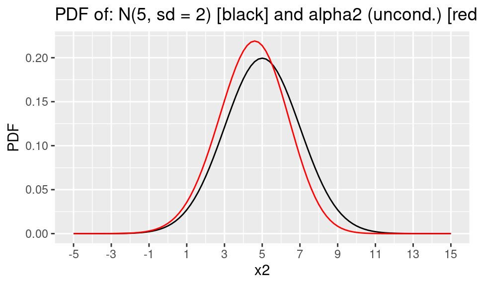

```r
    f <- function(x2, mu1 = 8, mu2 = 5, sd1 = 2, sd2 = 2) {
      phi <- dnorm
      Phi <- pnorm
      to_integrate <- function(x1, mu1, mu2, sd1, sd2) {
        phi((x1 - mu1) / sd1) / Phi((x1 - mu2) / sd2)
      }
      intgrl <- integrate(
        to_integrate,
        lower = x2, upper = Inf,
        mu1 = mu1, mu2 = mu2, sd1 = sd1, sd2 = sd2
      )
      1 / (sd1 * sd2) * phi((x2 - mu2) / sd2) * intgrl$value
    }
    f <- Vectorize(f)

    ggplot() +
      geom_function(fun = dnorm, colour = "black", args = list(mean = 5, sd = 2)) +
      geom_function(fun = f, colour = "red") +
      scale_x_continuous(breaks = seq(-5, 15, 2), limits = c(-5, 15)) +
      xlab("x2") +
      ylab("PDF") +
      ggtitle("PDF of: N(5, sd = 2) [black] and alpha2 (uncond.) [red]")
```

```r
    optimize(f, interval = c(1, 7), maximum = TRUE)
```

```
## $maximum
## [1] 4.600697
##
## $objective
## [1] 0.2189738
```

   However, I think we need to make sure the sample that is being obtained by this is indeed from an unconditional distribution of $\alpha_j$, $j = 2, \ldots, c-1$.

### 1.2.2 Multivariate Truncated Normal Distribution

We specify this prior for model $\eqref{model}$.

This approach allows a user for a full control of var-cov structure of random vector $\boldsymbol \alpha$. Following [15], we specify distribution of $\boldsymbol \alpha$ as multivariate truncated normal distribution. Consider first $\boldsymbol \alpha^* \sim N_{c-1}(\boldsymbol \mu, \Sigma)$. Now, let $\boldsymbol \alpha$ be truncation of $\boldsymbol \alpha^*$ above $\boldsymbol k \in \mathbb R^{c-1}$. $\boldsymbol \alpha$ has a $(c-1)$-variate truncated normal distribution given by
$$f_{\boldsymbol \alpha}(\boldsymbol x; \boldsymbol \mu, \Sigma,
\boldsymbol k) =
\frac{exp\{-\tfrac{1}{2}(\boldsymbol x - \boldsymbol \mu)^T \Sigma
(\boldsymbol x - \boldsymbol \mu)\}}
{\idotsint_{R^{c-1}_{\leq \boldsymbol k}} exp\{-\tfrac{1}{2}(\boldsymbol
x - \boldsymbol \mu)^T \Sigma (\boldsymbol x - \boldsymbol \mu)\} \,dx_1
\dots dx_{c-1}}$$
where
$$\begin{aligned}
\boldsymbol x &\in \mathbb R^{c-1}_{\leq \boldsymbol k} \\
\boldsymbol \mu &\in \mathbb R^{c-1} \\
\Sigma &\text{ is } (c-1) \times (c-1) \text{ var-cov matrix,} \\
\boldsymbol k &\in \mathbb R^{c-1},
\end{aligned}$$
with $c \geq 2$. Due to CLM model restriction $\eqref{alpha_ordering}$, we further require that $\boldsymbol k = [k_1, k_2, \ldots, k_{c-1}]^T$ is such that $\infty = k_1 > k_2 > \cdots > k_{c-1} > -\infty$. Note that for $c = 2$ we obtain a univariate normal distribution without truncation, which somehow corresponds to $\alpha_1$ in $\eqref{prior1}$.

Unfortunately, the marginals of multivariate truncated normal variates do not need to be truncated normal in general. The exact formula for the marginal probability densities functions are given in [16].

Then, in JAGS we would simply need to generate these marginal r.vs. (see also `tmvtnorm` R package)

### 1.2.3 Transformation of the intercepts to an unconstrained space

$\delta_1$ := $log(\alpha_1)$, $\delta_j$ := $log(\alpha_j - \alpha_{j-1})$, $j = 2, \ldots, c - 1 \geq 2$. Then, e.g. $\boldsymbol \delta \sim \mathcal{N}_{c-1}(\mu, \Sigma)$.

Note that it is required that $\alpha_1$ > $0$.

See Albert and Chib (1997) for more details.

### 1.2.4 An ordered uniform distribution (Ishwaran, 2000)

This approach was mentioned in few sources, but it is still a bit unclear to me. For instance, in Congdon (2005), on page 239, the author writes: “An alternative suggested by Ishwaran (2000) is a uniform density
$$0 = \alpha_1 < \alpha_2 < \cdots < \alpha_{c-1} = U,$$
where $U$ is equal to or less than $c$.” I think this approach is about to a simple sequence or non overlapping uniform distributions.

### 1.2.5 Latent response model

With this approach, the observed response $Y$ is often taken to reflect an underlying continuous random variable $Y^*$ with $c-1$ thresholds or cut points. Albert and Chib (1993) presented a Bayesian analysis that utilizes the latent (response) variable model:
$$Y^*_i = \mathbf x_i^T \boldsymbol\beta + \epsilon_i, \qquad i \geq 1,$$
where $\epsilon_i$ are iid and $\epsilon_i \sim \mathcal{N}(0, 1), i \geq 1$. Here we have that
$$Y_i = j \quad \text{iff} \quad \alpha_{j-1} < Y^*_i \leq \alpha_j,
\quad j = 2, \ldots, c - 1,$$
where $\alpha_0 := -\infty$ and $\alpha_c := \infty$.

Following Congdon (2005) (see Chapter 7.2) that is based on Johnson and Albert (1999) (Chapter 4.3), the cut points are sampled in a way that takes account of the sampled $Y^*$. Thus, at iteration $t$:
$$\alpha^{(t)}_j \sim \mathcal{N}(0, V_{\alpha})\, T(L_j, U_j), \quad j =
1, \ldots, c-1,\\$$
where $V_{\alpha}$ is preset and
$$L_j = max(Y^{*(t)},\, Y_i = j) \\
U_j = min(Y^{*(t)},\, Y_i = j+1)$$
and
$$Y_i^* \sim \mathcal{N}(\mathbf x_i^T \boldsymbol\beta, \gamma_i)\,
T(\alpha_{y_{i-1}}, \alpha_{y_i}),$$
where $\gamma_i \sim Ga(0.5v, 0.5v)$, with $v$ preset.

# 2 Implementation

Add to `Data-class.R`

```r
# DataOrdinal ----

## class ----

#' `DataOrdinal`
#'
#' @description `r lifecycle::badge("experimental")`
#'
#' [`DataOrdinal`] is a class ordinal toxicity data.
#' It inherits from [`GeneralData`] and it describes toxicity responses on an
#' ordinal rather than binary scale.
#'
#' @note This class has been implemented as a sibling of the existing `Data` class
#' (rather than as a parent or child) to minimise the risk of unintended side
#' effects on existing classes and methods.
#'
#' @note The default setting for the `yCategories` slot replicates the behaviour
#' of the existing `Data` class.
#'
#' @inheritParams Data
#' @aliases DataOrdinal
#' @export
.DataOrdinal <- setClass(
  Class = "DataOrdinal",
  contains = "GeneralData",
  slots = c(
    x = "numeric",
    y = "integer",
    doseGrid = "numeric",
    nGrid = "integer",
    xLevel = "integer",
    yCategories = "integer",
    placebo = "logical"
  ),
  prototype = prototype(
    x = numeric(),
    y = integer(),
    doseGrid = numeric(),
    nGrid = 0L,
    xLevel = integer(),
    yCategories = c("No DLT" = 0L, "DLT" = 1L),
    placebo = FALSE
  )
  # ,
  # validity = v_data_ordinal
)

## constructor ----

#' @rdname DataOrdinal-class
#' @param yCategories (`named integer vector`)\cr the names and codes for the
#' toxicity categories used in the data.  Category labels are taken from the
#' names of the vector.  The names of the vector must be unique and its values
#' must be sorted and take the values 0, 1, 2, ...##'
#' @inherit Data details note params
#' @example examples/Data-class-DataOrdinal.R
#' @export
DataOrdinal <- function(
    x = numeric(),
    y = integer(),
    ID = integer(),
    cohort = integer(),
    doseGrid = numeric(),
    placebo = FALSE,
    yCategories = c("No DLT" = 0L, "DLT" = 1L),
    ...
) {
  assert_numeric(x)
  assert_numeric(y)
  assert_numeric(ID)
  assert_numeric(cohort)
  assert_numeric(doseGrid, any.missing = FALSE, unique = TRUE)
  assert_numeric(yCategories, any.missing = FALSE, unique = TRUE)
  assert_character(names(yCategories), any.missing = FALSE, unique = TRUE)
  assert_flag(placebo)

  doseGrid <- as.numeric(sort(doseGrid))

  if (length(ID) == 0 && length(x) > 0) {
    message("Used default patient IDs!")
    ID <- seq_along(x)
  }

  if (!placebo && length(cohort) == 0 && length(x) > 0) {
    message("Used best guess cohort indices!")
    # This is just assuming that consecutive patients
    # in the data set are in the same cohort if they
    # have the same dose. Note that this could be wrong,
    # if two subsequent cohorts are at the same dose.
    cohort <- as.integer(c(1, 1 + cumsum(diff(x) != 0)))
  }

  .DataOrdinal(
    x = as.numeric(x),
    y = y,
    ID = ID,
    cohort = cohort,
    doseGrid = doseGrid,
    nObs = length(x),
    nGrid = length(doseGrid),
    xLevel = matchTolerance(x = x, table = doseGrid),
    placebo = placebo,
    yCategories = yCategories
  )
}
```

Create a test object

```r
ordinal_data <- DataOrdinal(
  doseGrid = seq(10, 100, 10),
  x = c(10, 20, 30, 40, 50, 50, 50),
  y = c(0L, 0L, 0L, 0L, 0L, 1L, 2L),
  ID = 1L:7L,
  cohort = as.integer(c(1:4, 5, 5, 5)),
  yCategories = c("No Tox" = 0L, "Sub tox AE" = 1L, "DLT" = 2L)
)

ordinal_data
```

```
## An object of class "DataOrdinal"
## Slot "x":
## [1] 10 20 30 40 50 50 50
##
## Slot "y":
## [1] 0 0 0 0 0 1 2
##
## Slot "doseGrid":
##  [1]  10  20  30  40  50  60  70  80  90 100
##
## Slot "nGrid":
## [1] 10
##
## Slot "xLevel":
## [1] 1 2 3 4 5 5 5
##
## Slot "yCategories":
##     No Tox Sub tox AE        DLT
##          0          1          2
##
## Slot "placebo":
## [1] FALSE
##
## Slot "ID":
## [1] 1 2 3 4 5 6 7
##
## Slot "cohort":
## [1] 1 2 3 4 5 5 5
##
## Slot "nObs":
## [1] 7
```

### 2.0.1 update-DataOrdinal

Add to `data-methods-R`

```r
## DataOrdinal ----

#' Updating `DataOrdinal` Objects
#'
#' @description `r lifecycle::badge("experimental")`
#'
#' A method that updates existing [`DataOrdinal`] object with new data.
#'
#' @param object (`DataOrdinal`)\cr object you want to update.
#' @param x (`number`)\cr the dose level (one level only!).
#' @param y (`integer`)\cr the DLT vector for all patients in this
#'   cohort. You can also supply `numeric` vectors, but these will then be
#'   converted to `integer` internally.
#' @param ID (`integer`)\cr the patient IDs.
#'   You can also supply `numeric` vectors, but these will then be converted to
#'   `integer` internally.
#' @param new_cohort (`flag`)\cr if `TRUE` (default) the new data are assigned
#'   to a new cohort.
#' @param check (`flag`)\cr whether the validation of the updated object should
#'   be conducted. Current implementation of this `update` method allows for
#'   updating the `DataOrdinal` class object by adding a single dose level `x` only.
#'   However, there might be some use cases where the new cohort to be added
#'   contains a placebo and active dose. Hence, such update would need to be
#'   performed iteratively by calling the `update` method twice. For example,
#'   in the first call a user can add a placebo, and then in the second call,
#'   an active dose. Since having a cohort with placebo only is not allowed,
#'   the `update` method would normally throw the error when attempting to add
#'   a placebo in the first call. To allow for such updates, the `check`
#'   parameter should be then set to `FALSE` for that first call.
#' @param ... not used.
#'
#' @return The new, updated [`DataOrdinal`] object.
#'
#' @rdname update-DataOrdinal
#' @export
#' @example examples/DataOrdinal-method-update.R
#'
setMethod(
  f = "update",
  signature = signature(object = "DataOrdinal"),
  definition = function(object,
                        x,
                        y,
                        ID = length(object@ID) + seq_along(y),
                        new_cohort = TRUE,
                        check = TRUE,
                        ...) {
    assert_numeric(x, min.len = 0, max.len = 1)
    assert_numeric(y, lower = 0, upper = length(object@yCategories) - 1)
    assert_numeric(ID, len = length(y))
    assert_disjunct(object@ID, ID)
    assert_flag(new_cohort)
    assert_flag(check)

    # How many additional patients, ie. the length of the update.
    n <- length(y)

    # Which grid level is the dose?
    gridLevel <- matchTolerance(x, object@doseGrid)
    object@xLevel <- c(object@xLevel, rep(gridLevel, n))

    # Add dose.
    object@x <- c(object@x, rep(as.numeric(x), n))

    # Add DLT data.
    object@y <- c(object@y, y)

    # Add ID.
    object@ID <- c(object@ID, ID)

    # Add cohort number.
    new_cohort_id <- if (object@nObs == 0) {
      1L
    } else {
      tail(object@cohort, 1L) + ifelse(new_cohort, 1L, 0L)
    }
    object@cohort <- c(object@cohort, rep(new_cohort_id, n))

    # Increment sample size.
    object@nObs <- object@nObs + n

    if (check) {
      validObject(object)
    }

    object
  }
)

update(ordinal_data, x = 60, y = c(0L, 1L, 0L))
```

```
## An object of class "DataOrdinal"
## Slot "x":
##  [1] 10 20 30 40 50 50 50 60 60 60
##
## Slot "y":
##  [1] 0 0 0 0 0 1 2 0 1 0
##
## Slot "doseGrid":
##  [1]  10  20  30  40  50  60  70  80  90 100
##
## Slot "nGrid":
## [1] 10
##
## Slot "xLevel":
##  [1] 1 2 3 4 5 5 5 6 6 6
##
## Slot "yCategories":
##     No Tox Sub tox AE        DLT
##          0          1          2
##
## Slot "placebo":
## [1] FALSE
##
## Slot "ID":
##  [1]  1  2  3  4  5  6  7  8  9 10
##
## Slot "cohort":
##  [1] 1 2 3 4 5 5 5 6 6 6
##
## Slot "nObs":
## [1] 10
```

### 2.0.2 dose_grid_range-DataOrdinal

Add to `data-Methods.R`

```r
## DataOrdinal ----
#' @include Data-methods.R
#' @rdname dose_grid_range
#'
#' @param ignore_placebo (`flag`)\cr should placebo dose (if any) not be counted?
#'
#' @aliases dose_grid_range-Data
#' @example examples/DataOrdinal-method-dose_grid_range.R
#'
setMethod(
  f = "dose_grid_range",
  signature = signature(object = "DataOrdinal"),
  definition = function(object, ignore_placebo = TRUE) {
    assert_flag(ignore_placebo)

    dose_grid <- if (ignore_placebo && object@placebo && object@nGrid >= 1) {
      object@doseGrid[-1]
    } else {
      object@doseGrid
    }

    if (length(dose_grid) == 0L) {
      c(-Inf, Inf)
    } else {
      range(dose_grid)
    }
  }
)

dose_grid_range(ordinal_data)
```

```
## [1]  10 100
```

### 2.0.3 plot-DataOrdinal

Much of the code in `plot` is common to objects of both `Data` and `DataOrdinal`, but there are some differences. If `DataOrdinal` were the super-class of `Data` (or vice versa), we could use standard inheritance to reuse the common code. But they are siblings. So introduce new helper function and modify the body of `plot-Data` accordingly. Place the helper functions in a new file `helpers-data.R`.

`helpers-data.R`

```r
h_blind_plot_data <- function(df, blind, has_placebo, pbo_dose) {
  if (blind) {
    # This is to blind the data.
    # For each cohort, all DLTs are assigned to the first subjects in the cohort.
    # In addition, the placebo (if any) is set to the active dose level for that
    # cohort.
    # Notice: dapply reorders records of df according to the lexicographic order
    # of cohort.
    df <- dapply(df, f = ~cohort, FUN = function(coh) {
      coh$toxicity <- sort(coh$toxicity, decreasing = TRUE)
      coh$dose <- max(coh$dose)
      coh
    })
  } else if (has_placebo) {
    # Placebo will be plotted at y = 0 level.
    df$dose[df$dose == pbo_dose] <- 0
  }
  df
}

# h_plot_data_df ----

## generic ----

#' Helper Function for the Plot Method of subclasses of [`GeneralData`]
#'
#' @description `r lifecycle::badge("experimental")`
#'
#' A method that transforms [`GeneralData`]  objects into a `tibble` suitable for
#' plotting with `ggplot2` methods
#'
#' @param data (`GeneralData`)\cr object from which data is extracted and converted
#' into a data frame.
#' @param ... further arguments passed to class-specific methods.
#' @return `data.frame` containing columns for patient, cohort, dose and toxicity grade
#' @aliases h_plot_data_df
#'
setGeneric(
  name = "h_plot_data_df",
  def = function(data, ...) standardGeneric("h_plot_data_df"),
  valueClass = "data.frame"
)
```

```
## [1] "h_plot_data_df"
```

```r
# Data ----

#' Helper Function for the Plot Method of [`Data`]
#'
#' @param data (`Data`)\cr object from which data is extracted and converted
#'   into a data frame.
#' @param blind (`flag`)\cr should data be blinded?
#'   If `TRUE`, then for each cohort, all DLTs are assigned to the first
#'   subjects in the cohort. In addition, the placebo (if any) is set to the
#'   active dose level for that cohort.
#' @param legend (`flag`)\cr Display the legend for the toxicity categories
#' @param ... further arguments passed to `data.frame` constructor.
#'   It can be e.g. an extra `column_name = value` pair based on a slot
#'   from `x` (which in this case might be a subclass of `Data`)
#'   which does not appear in `Data`.
#' @return A [`data.frame`] object with columns patient, ID, cohort, dose and
#' toxicity.
#' @describeIn h_plot_data_df Class specific method for [`Data`]
setMethod(
  f = "h_plot_data_df",
  signature = signature(data = "Data"),
  definition = function(data, blind = FALSE, legend = TRUE, ...) {
    df <- data.frame(
      patient = seq_along(data@x),
      ID = paste(" ", data@ID),
      cohort = data@cohort,
      dose = data@x,
      toxicity = ifelse(data@y == 1, "Yes", "No"),
      ...
    )
    df <- h_blind_plot_data(df, blind, data@placebo, data@doseGrid[1])
    df
  }
)

# DataOrdinal ----

#' Helper Function for the Plot Method of [`DataOrdinal`]
#'
#' @param data (`DataOrdinal`)\cr object from which data is extracted and converted
#'   into a data frame.
#' @param blind (`flag`)\cr should data be blinded?
#'   If `TRUE`, then for each cohort, all DLTs are assigned to the first
#'   subjects in the cohort. In addition, the placebo (if any) is set to the
#'   active dose level for that cohort.
#' @param ... further arguments passed to `data.frame` constructor.
#'   It can be e.g. an extra `column_name = value` pair based on a slot
#'   from `x` (which in this case might be a subclass of `Data`)
#'   which does not appear in `Data`.
#' @return A [`data.frame`] object with values to plot.
#' @describeIn h_plot_data_df Class specific method for [`DataOrdinal`]
setMethod(
  f = "h_plot_data_df",
  signature = signature(data = "DataOrdinal"),
  definition = function(data, blind = FALSE, legend = TRUE, ...) {
    df <- data.frame(
      patient = seq_along(data@x),
      ID = paste(" ", data@ID),
      cohort = data@cohort,
      dose = data@x,
      toxicity = names(data@yCategories)[1 + data@y],
      ...
    )
    df <- h_blind_plot_data(df, blind, data@placebo, data@doseGrid[1])
    df
  }
)


# h_plot_data_dataordinal

## Data ----

#' Helper Function for the Plot Method of the Data and DataOrdinal Classes
#'
#' @description `r lifecycle::badge("stable")`
#'
#' A method that creates a plot for [`Data`]  and [`DataOrdinal`] objects.
#'
#' @param x (`Data`)\cr object we want to plot.
#' @param y (`missing`)\cr missing object, for compatibility with the generic
#'   function.
#' @param blind (`flag`)\cr indicates whether to blind the data.
#'   If `TRUE`, then placebo subjects are reported at the same level
#'   as the active dose level in the corresponding cohort,
#'   and DLTs are always assigned to the first subjects in a cohort.
#' @param tox_labels (`character`)\cr the toxicity category labels
#' @param tox_shapes (`integer`)\cr the shapes used to plot the various toxicity
#' categories
#' @param legend (`flag`)\cr whether the legend should be added.
#' @param ... not used.
#'
#' @note The default values of `tox_shapes` and `tox_labels` result in DLTs
#' being displayed as red triangles and other responses as black circles.
#' @return The [`ggplot2`] object.
#'
#' @rdname plot-Data
h_plot_data_dataordinal <- function(
    x,
    blind = FALSE,
    legend = TRUE,
    tox_labels = c(Yes = "red", No = "black"),
    tox_shapes = c(Yes = 17L, No = 16L),
    ...) {
  assert_flag(blind)
  assert_flag(legend)
  assert_character(tox_labels, any.missing = FALSE, unique = TRUE)
  assert_integer(tox_shapes, any.missing = FALSE, unique = TRUE)
  assert_true(length(tox_shapes) == length(tox_labels))
  assert_subset(x@y, as.integer(0:(length(tox_shapes) - 1)))
    if (x@nObs == 0L) {
    return()
  }
  df <- h_plot_data_df(x, blind, ...)

  p <- ggplot(df, aes(x = patient, y = dose)) +
    geom_point(aes(shape = toxicity, colour = toxicity), size = 3) +
    scale_colour_manual(
      name = "Toxicity",
      values = tox_labels,
      breaks = names(tox_labels),
      guide = guide_legend(reverse = TRUE)
    ) +
    scale_shape_manual(
      name = "Toxicity",
      values = tox_shapes,
      breaks = names(tox_shapes),
      guide = guide_legend(reverse = TRUE)
    ) +
    scale_x_continuous(breaks = df$patient, minor_breaks = NULL) +
    scale_y_continuous(
      breaks = sort(unique(c(0, df$dose))),
      minor_breaks = NULL,
      limits = c(0, max(df$dose) * 1.1)
    ) +
    xlab("Patient") +
    ylab("Dose Level")

  p <- p + crmPack:::h_plot_data_cohort_lines(df$cohort, placebo = x@placebo)

  if (!blind) {
    p <- p +
      geom_text(
        aes(label = ID, size = 2),
        data = df,
        hjust = 0,
        vjust = 0.5,
        angle = 90,
        colour = "black",
        show.legend = FALSE
      )
  }

  if (!legend) {
    p <- p + theme(legend.position = "none")
  }

  p
}
```

Modify `plot-Data` in `Data-methods.R`

```r
#' Plot Method for the [`Data`] Class
#'
#' @description `r lifecycle::badge("stable")`
#'
#' A method that creates a plot for [`Data`] object.
#'
#' @rdname plot-Data
#' @export
#' @example examples/Data-method-plot.R
#'
setMethod(
  f = "plot",
  signature = signature(x = "Data", y = "missing"),
  definition = function(x, y, blind = FALSE, legend = TRUE, ...) {
    h_plot_data_dataordinal(x, blind, legend, ...)
  }
)
```

Add to `Data-methods.R`

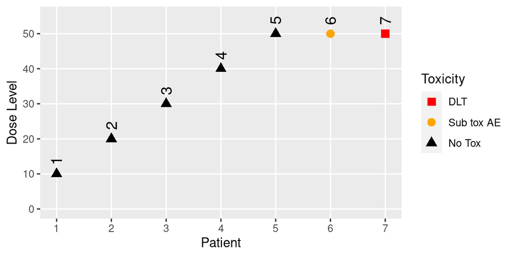

```r
## DataOrdinal ----

#' Plot Method for the [`DataOrdinal`] Class
#'
#' @description `r lifecycle::badge("experimental")`
#'
#' A method that creates a plot for [`DataOrdinal`] object.
#'
#' @param x (`DataOrdinal`)\cr object we want to plot.
#' @param y (`missing`)\cr missing object, for compatibility with the generic
#'   function.
#' @param blind (`flag`)\cr indicates whether to blind the data.
#'   If `TRUE`, then placebo subjects are reported at the same level
#'   as the active dose level in the corresponding cohort,
#'   and DLTs are always assigned to the first subjects in a cohort.
#' @param legend (`flag`)\cr whether the legend should be added.
#' @param tox_labels (`named list of character`)\cr The labels of the toxicity
#' categories
#' @param tox_shapes (`names list of integers`)\cr The symbols used to identify
#' the toxicity categories
#' @param ... not used.
#'
#' @note With more than 9 toxicity categories, toxicity symbols must be
#' specified manually.\cr With more than 5 toxicity categories, toxicity labels
#' must be specified manually.
#'
#' @return The [`ggplot2`] object.
#'
#' @rdname plot-Data
#' @export
#' @example examples/DataOrdinal-method-plot.R
setMethod(
  f = "plot",
  signature = signature(x = "DataOrdinal", y = "missing"),
  definition = function(
    x,
    y,
    blind = FALSE,
    legend = TRUE,
    tox_labels = NULL,
    tox_shapes = NULL,
    ...
  ) {
    if (is.null(tox_shapes)) {
      assert_true(length(x@yCategories) <= 9)
      tox_shapes <- c(17L, 16L, 15L, 18L, 0L:2L, 5L, 6L)[seq_along(x@yCategories)]
      names(tox_shapes) <- names(x@yCategories)
    }
    if (is.null(tox_labels)) {
      assert_true(length(x@yCategories) <= 5)
      tox_labels <- switch(
                  length(x@yCategories),
                  c("black"),
                  c("black", "red"),
                  c("black", "orange", "red"),
                  c("black", "green", "orange", "red"),
                  c("black", "green", "yellow", "orange", "red")
      )
      names(tox_labels) <- names(x@yCategories)
    }
    h_plot_data_dataordinal(
      x,
      blind,
      legend,
      tox_labels = tox_labels,
      tox_shapes = tox_shapes,
      ...
    )
  }
)

plot(ordinal_data)
```

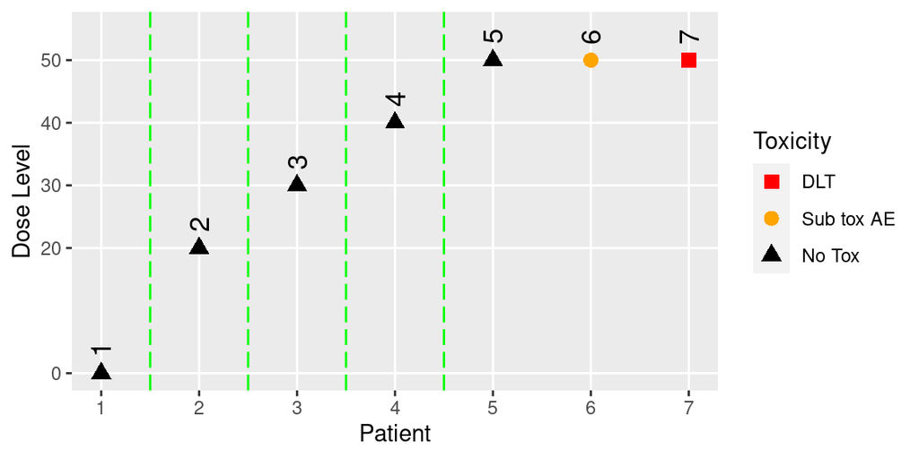

```r
ordinal_data1 <- ordinal_data
ordinal_data1@placebo <- TRUE

plot(ordinal_data1)
```

And, as a regression check…

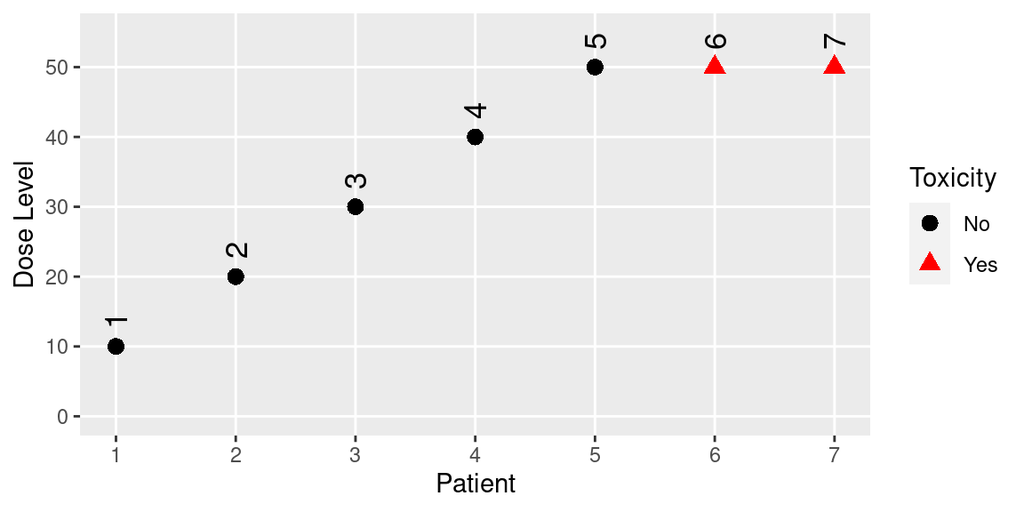

```r
binary_data <- Data(
  doseGrid = seq(10, 100, 10),
  x = c(10, 20, 30, 40, 50, 50, 50),
  y = c(0L, 0L, 0L, 0L, 0L, 1L, 1L),
  ID = 1L:7L,
  cohort = as.integer(c(1:4, 5, 5, 5))
)

plot(binary_data)
```

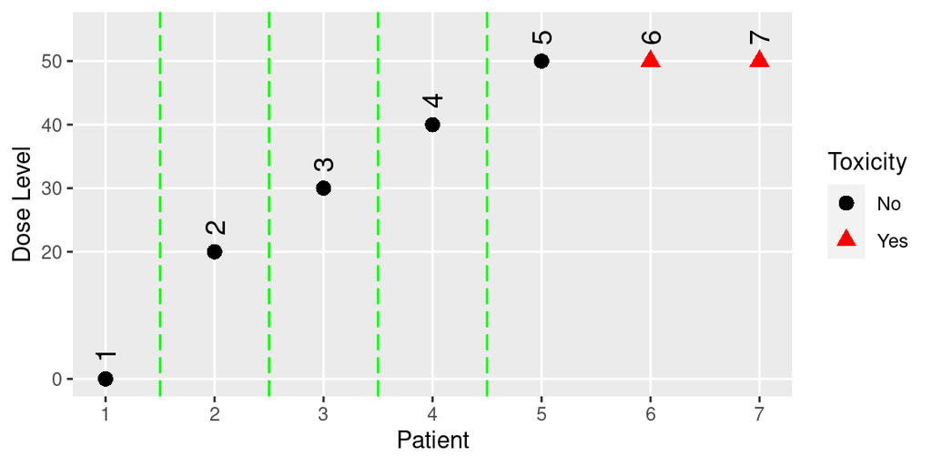

```r
binary_data1 <- binary_data
binary_data1@placebo <- TRUE

plot(binary_data1)
```

## 2.1 Model-class (LogisticLogNormalOrdinal)

For simplicity of notation, unless we need to refer to particular subjects or to particular values of the explanatory variables, we replace $p_{ij}$ (i.e. $P(X_i \geq j)$) in such equations by $p_j$ (i.e. $P(Y \geq j)$), keeping in mind that in the model this is actually a conditional probability at each fixed value for the explanatory variables.

The following basic CLM can be considered as a single-agent toxicity model, in which the covariate is the natural logarithm of the dose $x$ divided by the reference dose $x^*$, i.e.:
$$logit[p_j] = \alpha_j + \beta \, log(\tfrac{x}{x^*}), \quad j = 1,
\ldots, c-1.$$
The prior is:
$$log(\beta) \sim N(\mu_{\beta}, \sigma_{\beta}^2)$$
and for $\{\alpha_j\}_{j \in \{1, \ldots, c-1\}}$ we propose prior as in $\eqref{prior1}$.

Even though we restrict the covariance matrix to be diagonal for this class, specify the covariance as a matrix rather than a vector for consistency with other classes, and check that it is diagonal in `ValidObject()`.

Add to `Model-class.R`.

```r
## class ----

#' `OrdinalLogisticLogNormal`
#'
#' @description `r lifecycle::badge("experimental")`
#'
#' [`OrdinalLogisticLogNormal`] is the class for a logistic lognormal CRM model
#' using an ordinal toxicity scale.
#'
#' @aliases OrdinalLogisticLogNormal
#' @export
#'

.LogisticLogNormalOrdinal <- setClass(
  Class = "LogisticLogNormalOrdinal",
  contains = "ModelLogNormal",
  slots = c(datablock = "function")
  # ,
  # validity = v_model_ordinal_logistic_log_normal
)

## constructor ----

#' @rdname LogisticLogNormalOrdinal-class
#' @inheritParams ModelLogNormal
#' @export
#' @example examples/Model-class-LogisticLogNormalOrdinal.R
#'

LogisticLogNormalOrdinal <- function(mean, cov, ref_dose) {
  params <- ModelParamsNormal(mean, cov)
  .LogisticLogNormalOrdinal(
    params = params,
    ref_dose = crmPack:::positive_number(ref_dose),
    priormodel = function() {
      alpha[1] ~ dnorm(mean[1], prec[1, 1])
      for (i in 2:(k-1)) {
        alpha[i] ~ dnorm(mean[i], prec[i, i]) %_% T( , alpha[i-1])
      }
      gamma ~ dnorm(mean[k], prec[k, k])
      beta <- exp(gamma)
    },
    datamodel = function() {
      for (i in 1:nObs) {
        xhat[i] <- log(x[i] / ref_dose)
        for (j in 1:(k-1)) {
          z[i, j] <- alpha[j] + beta * xhat[i]
          p[i, j] <- exp(z[i, j]) / (1 + exp(z[i, j]))
          tox[i, j] ~ dbern(p[i, j])
        }
      }
    },
    modelspecs = function(y, from_prior) {
      ms <- list(
        mean = params@mean,
        prec = params@prec,
        k = length(mean),
        tox = array(dim = c(length(y), length(mean) - 1))
      )
      if (!from_prior) {
        for (i in 1:length(y)) {
          for (j in 1:(ms$k-1)) {
            ms$tox[i, j] <- y[i] >= j
          }
        }
        ms$ref_dose <- ref_dose
      }
      ms
    },
    init = function() {
      list(alpha = sapply(1:(length(mean)-1), function(x) -(x+1)), gamma = 1)
    },
    datanames = c("nObs", "y", "x"),
    sample = c(paste0("alpha[", 1:(length(mean) - 1), "]"), "beta")
  )
}

## default constructor ----

#' @rdname LogisticLogNormalOrdinal-class
#' @note Typically, end users will not use the `.DefaultLogisticLogNormalOrdinal()` function.
#' @export

.DefaultLogisticLogNormalOrdinal <- function() {
  LogisticLogNormalOrdinal(
    mean=c(-3, -4, 1),
    cov=diag(c(3, 4, 1)),
    ref_dose = 50
  )
}

ordinal_data <- DataOrdinal(
  doseGrid = seq(10, 100, 10),
  x = c(10, 20, 30, 40, 50, 50, 50),
  y = c(0L, 0L, 0L, 0L, 0L, 1L, 2L),
  ID = 1L:7L,
  cohort = as.integer(c(1:4, 5, 5, 5)),
  yCategories = c("No Tox" = 0L, "Sub tox AE" = 1L, "DLT" = 2L)
)

ordinal_model <- .DefaultLogisticLogNormalOrdinal()
```

### 2.1.1 mcmc-LogisticLogNormalOrdinal

`mcmc` requires no change.

```r
ordinal_data <- DataOrdinal(
  doseGrid = seq(10, 100, 10),
  x = c(10, 20, 30, 40, 50, 50, 50),
  y = c(0L, 0L, 0L, 0L, 0L, 1L, 2L),
  ID = 1L:7L,
  cohort = as.integer(c(1:4, 5, 5, 5)),
  yCategories = c("No Tox" = 0L, "Sub tox AE" = 1L, "DLT" = 2L)
)

mcmc_options <- McmcOptions()

samples <- mcmc(ordinal_data, ordinal_model, mcmc_options)
```

```
## Warning in rjags::jags.model(file = model_file, data = model_data, inits =
## c(model_inits, : Unused variable "y" in data
```

> The `modelspecs` function transforms the `y` vector in `DataOrdinal` to the `ms$tox` matrix of indicator flags. `tox` is what is actually used in the model fitting. `y` is superfluous at that stage. How can we prevent the warning? That is, remove it from the JAGS environment.

### 2.1.2 prob-Samples-LogisticLogOrdinalModel

Existing `prob` functions have to deal only with binary data and hence there is no sense of cumulative probabilities. The ordinal model has that possibility. In addition, probabilities associated with a particular toxicity grade may be of interest in the ordinal model. Therefore, introduce two new parameters: `grade`, indicating the toxicity grade9s) for which probabioities are required, and `cumulative`, a flag indicating whether or not cumulative probabilities are of interest.

> In the existing `prob-Samples-LogisticLogNormal`, the parameters in the validity check for `names(samples)` are reversed, leading to a potentially misleading error message.

```r
## LogisticLogNormal ----

#' @describeIn prob
#' @param category (`integer` or `integer_vector`)\cr The toxicity grade for which probabilities are required
#' @param cumulative (`flag`)\cr Should the returned probability be cumulative
#' (the default) or grade-specific?
#' @note
#' @aliases prob-LogisticLogNormalOrdinal
#' @export
#'
setMethod(
  f = "prob",
  signature = signature(
    dose = "numeric",
    model = "LogisticLogNormalOrdinal",
    samples = "Samples"
  ),
  definition = function(dose, model, samples, grade, cumulative = TRUE) {
    assert_numeric(dose, lower = 0L, any.missing = FALSE, min.len = 1L)
    assert_integer(
      grade,
      min.len = 1,
      max.len = length(model@params@mean) - 1,
      lower = 0,
      upper = length(model@params@mean) - 1
    )
    assert_subset(
      names(samples),
      c(paste0("alpha[", 0:(length(model@params@mean)-1), "]"), "beta")
    )
    assert_length(dose, len = size(samples))

    rv <- lapply(
      grade,
      function(g) {
        alpha <- samples@data[[paste0("alpha[", g, "]")]]
        beta <- samples@data$beta
        ref_dose <- as.numeric(model@ref_dose)

        cumulative_prob <- plogis(alpha + beta * log(dose / ref_dose))
        if (cumulative | g == as.integer(length(model@params@mean)-1)) return(cumulative_prob)

        # Calculate grade-specific probabilities
        alpha0 <- samples@data[[paste0("alpha[", g + 1, "]")]]
        grade_prob <- cumulative_prob - plogis(alpha0 + beta * log(dose / ref_dose))
        return(grade_prob)
      }
    )
    if (length(rv) == 1) return(rv[[1]])
    names(rv) <- as.character(grade)
    return(rv)
  }
)

prob(30, ordinal_model, samples, grade = 1L)[1:10]
```

```
##  [1] 0.003159814 0.025145504 0.040715516 0.028935600 0.080079275 0.184049107
##  [7] 0.021616717 0.125489501 0.033257091 0.074646508
```

```r
prob(30, ordinal_model, samples, grade = 2L)[1:10]
```

```
##  [1] 0.001699370 0.017734002 0.002358644 0.005104551 0.013053313 0.022293619
##  [7] 0.005805514 0.005828331 0.023051978 0.052336648
```

```r
prob(30, ordinal_model, samples, grade = 1L, cumulative = FALSE)[1:10]
```

```
##  [1] 0.001460444 0.007411502 0.038356872 0.023831049 0.067025962 0.161755488
##  [7] 0.015811202 0.119661170 0.010205114 0.022309860
```

Unfortunately, the existing generic does not allow `prob` to return a list. Therefore we will have to modify the generic or introduce a class-specific function to allow this. The code above assumes we modify the generic.

```r
prob(30, ordinal_model, samples,  grade = 1L:2L)
```

```
## Error in .valueClassTest(ans, "numeric", structure("prob", package = "crmPack")): invalid value from generic function 'prob', class "list", expected "numeric"
```

```r
# prob(30, ordinal_model, samples, grade = 1L:2L, cumulative = TRUE)
```

### 2.1.3 fit-Samples-LogisticLogNormalOrdinal

As with `prob` above, additional parameters to define the toxicity grade of interest and whether cumulative probabilities are requested. The existing `fit` fuunction could be used if the `...` parameters were passed to the call to `prob`.

```r
##' @param points at which dose levels is the fit requested? default is the dose
##' grid
##' @param quantiles the quantiles to be calculated (default: 0.025 and
##' 0.975)
##' @param middle the function for computing the middle point. Default:
##' \code{\link{mean}}
##'
##' @describeIn fit This method returns a data frame with dose, middle, lower
##' and upper quantiles for the dose-toxicity curve
##' @example examples/Sample-methods-fit.R
##'
setMethod("fit",
  signature =
    signature(
      object = "Samples",
      model = "GeneralModel",
      data = "DataOrdinal"
    ),
  def =
    function(object,
             model,
             data,
             points = data@doseGrid,
             quantiles = c(0.025, 0.975),
             middle = mean,
             ...) {
      ## some checks
      assert_probability_range(quantiles)
      assert_numeric(points)
      assert_function(middle)

      ## first we have to get samples from the dose-tox
      ## curve at the dose grid points.
      probSamples <- matrix(
        nrow = size(object),
        ncol = length(points)
      )

      ## evaluate the probs, for all samples.
      for (i in seq_along(points))
      {
        ## Now we want to evaluate for the
        ## following dose:
        probSamples[, i] <- prob(
          dose = points[i],
          model,
          object,
          ...
        )
      }

      ## extract middle curve
      middleCurve <- apply(probSamples, 2L, FUN = middle)

      ## extract quantiles
      quantCurve <- apply(probSamples, 2L, quantile,
        prob = quantiles
      )

      ## now create the data frame
      ret <- data.frame(
        dose = points,
        middle = middleCurve,
        lower = quantCurve[1, ],
        upper = quantCurve[2, ]
      )

      ## return it
      return(ret)
    }
)

fit(samples, ordinal_model, ordinal_data, grade = 2L)
```

```
##    dose      middle        lower      upper
## 1    10 0.003777837 1.610605e-18 0.03448751
## 2    20 0.009596515 2.497349e-11 0.07126208
## 3    30 0.020668769 4.334270e-07 0.11917961
## 4    40 0.044203346 2.658546e-04 0.19360348
## 5    50 0.108420343 5.598918e-03 0.36727769
## 6    60 0.258993163 1.057301e-02 0.91911497
## 7    70 0.386313785 1.491569e-02 0.99709920
## 8    80 0.477347149 1.930782e-02 0.99988243
## 9    90 0.543518718 2.337921e-02 0.99999288
## 10  100 0.593234835 2.811185e-02 0.99999937
```

```r
fit(samples, ordinal_model, ordinal_data, grade = 1L)
```

```
##    dose     middle        lower     upper
## 1    10 0.01564618 9.731947e-18 0.1355713
## 2    20 0.03963886 1.577051e-10 0.2438007
## 3    30 0.08424551 2.642346e-06 0.3576414
## 4    40 0.17204456 2.470293e-03 0.5060211
## 5    50 0.35727980 7.271646e-02 0.7457307
## 6    60 0.55832598 1.150566e-01 0.9863930
## 7    70 0.66670276 1.478706e-01 0.9996370
## 8    80 0.73141540 1.721704e-01 0.9999860
## 9    90 0.77408697 1.940548e-01 0.9999991
## 10  100 0.80426167 2.158287e-01 0.9999999
```

```r
fit(samples, ordinal_model, ordinal_data, grade = 1L, cumulative = FALSE)
```

```
##    dose     middle        lower     upper
## 1    10 0.01186835 5.301494e-18 0.1080306
## 2    20 0.03004235 9.138835e-11 0.2000220
## 3    30 0.06357674 1.680072e-06 0.2988926
## 4    40 0.12784121 9.649624e-04 0.4442153
## 5    50 0.24885945 1.271081e-02 0.6488163
## 6    60 0.29933282 1.003804e-02 0.7503154
## 7    70 0.28038898 1.161386e-03 0.7542097
## 8    80 0.25406826 6.791197e-05 0.7491590
## 9    90 0.23056825 4.239964e-06 0.7367136
## 10  100 0.21102683 3.429334e-07 0.7315533
```

```r
fit(samples, ordinal_model, ordinal_data, grade = 1L, cumulative = FALSE, middle = median)
```

```
##    dose       middle        lower     upper
## 1    10 0.0003156628 5.301494e-18 0.1080306
## 2    20 0.0056879626 9.138835e-11 0.2000220
## 3    30 0.0291240309 1.680072e-06 0.2988926
## 4    40 0.0907649313 9.649624e-04 0.4442153
## 5    50 0.2168040584 1.271081e-02 0.6488163
## 6    60 0.2662964257 1.003804e-02 0.7503154
## 7    70 0.2415742441 1.161386e-03 0.7542097
## 8    80 0.2053025933 6.791197e-05 0.7491590
## 9    90 0.1696918409 4.239964e-06 0.7367136
## 10  100 0.1386664551 3.429334e-07 0.7315533
```

### 2.1.4 `Samples-plot`

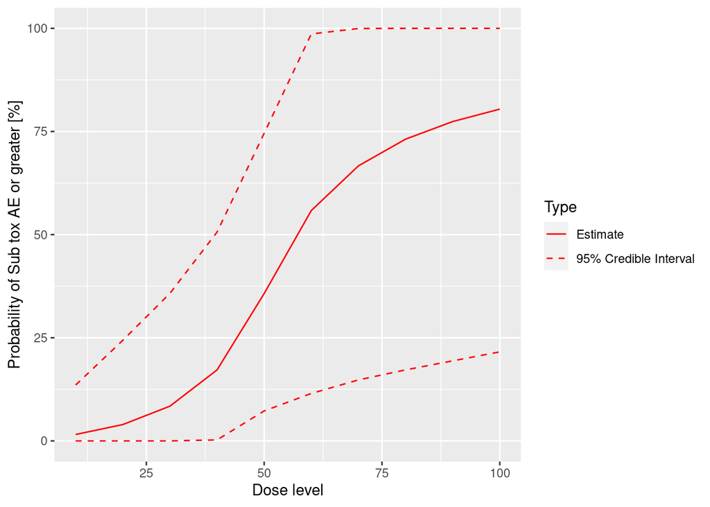

```r
## --------------------------------------------------
## Plot dose-tox fit from a model
## --------------------------------------------------


##' Plotting dose-toxicity model fits
##'
##' @param x the \code{\linkS4class{Samples}} object
##' @param y the \code{\linkS4class{GeneralModel}} object
##' @param data the \code{\linkS4class{Data}} object
##' @param xlab the x axis label
##' @param ylab the y axis label
##' @param showLegend should the legend be shown? (default)
##' @param \dots not used
##' @return This returns the \code{\link[ggplot2]{ggplot}}
##' object for the dose-toxicity model fit
##'
##' @example examples/Sample-methods-plot.R
##' @export
##' @importFrom ggplot2 qplot scale_linetype_manual
setMethod("plot",
  signature =
    signature(
      x = "Samples",
      y = "LogisticLogNormalOrdinal"
    ),
  def =
    function(x, y, data, ...,
             grade,
             xlab = "Dose level",
             showLegend = TRUE,
             cumulative = TRUE,
             ylab = ifelse(
               !is.null(data),
               paste0(
                 "Probability of ",
                 names(data@yCategories)[grade + 1] ,
                 ifelse(cumulative, " or greater", ""),
                 " [%]"
               ),
               "probability [%]"
             )) {
      ## check args
      assert_logical(showLegend)
      assert_logical(cumulative)

      ## get the fit
      plotData <- fit(x,
        model = y,
        data = data,
        quantiles = c(0.025, 0.975),
        middle = mean,
        grade = grade,
        cumulative = cumulative
      )

      ## make the plot
      gdata <-
        with(
          plotData,
          data.frame(
            x = rep(dose, 3),
            y = c(middle, lower, upper) * 100,
            group =
              rep(c("mean", "lower", "upper"),
                each = nrow(plotData)
              ),
            Type =
              factor(
                c(
                  rep(
                    "Estimate",
                    nrow(plotData)
                  ),
                  rep(
                    "95% Credible Interval",
                    nrow(plotData) * 2
                  )
                ),
                levels =
                  c(
                    "Estimate",
                    "95% Credible Interval"
                  )
              )
          )
        )

      ret <- ggplot2::qplot(
        x = x,
        y = y,
        data = gdata,
        group = group,
        linetype = Type,
        colour = I("red"),
        geom = "line",
        xlab = xlab,
        ylab = ylab,
        ylim = c(0, 100)
      )

      ret <- ret +
        ggplot2::scale_linetype_manual(
          breaks =
            c(
              "Estimate",
              "95% Credible Interval"
            ),
          values = c(1, 2), guide = ifelse(showLegend, "legend", "none")
        )

      return(ret)
    }
)

plot(x = samples, y = ordinal_model, data = ordinal_data, grade = 1L)
```

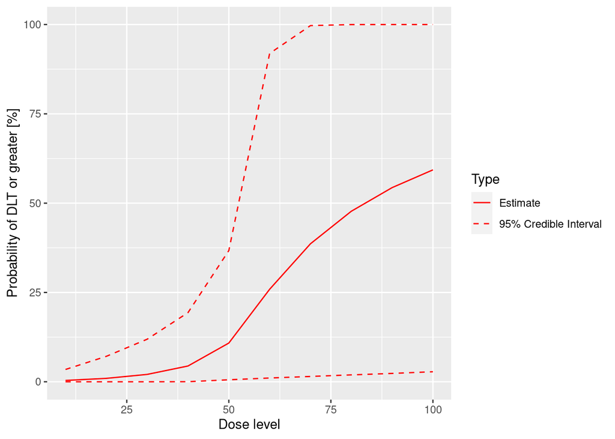

```r
plot(x = samples, y = ordinal_model, data = ordinal_data, grade = 2L)
```

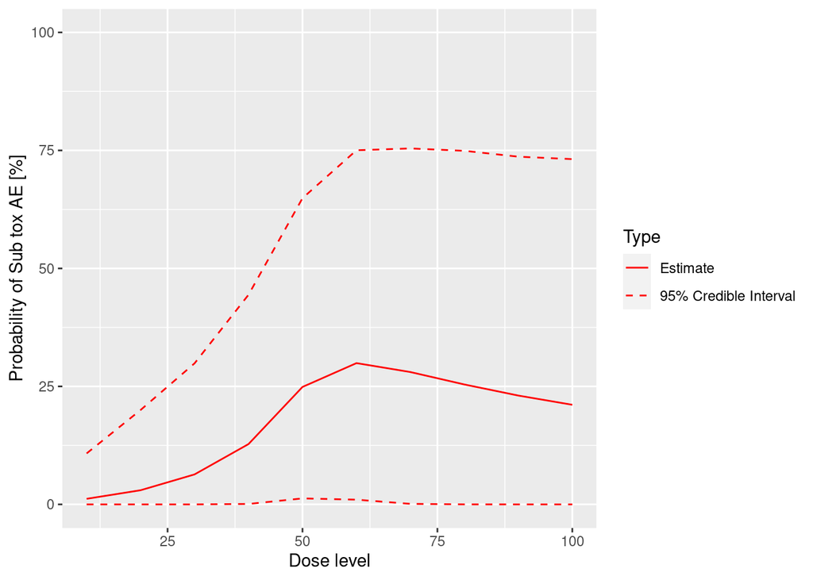

```r
plot(x = samples, y = ordinal_model, data = ordinal_data, grade = 1L, cumulative = FALSE)
```

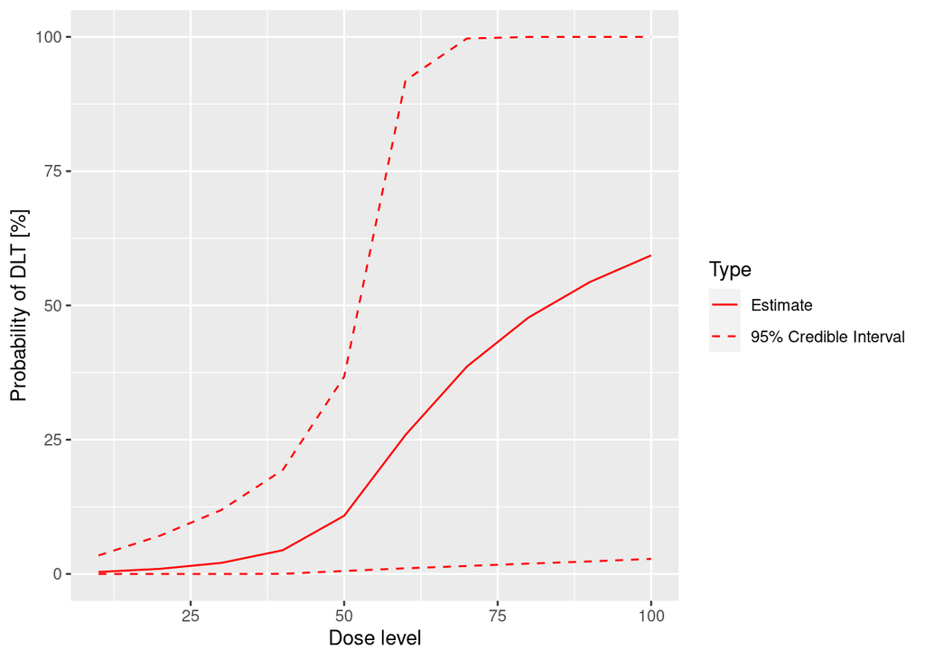

```r
plot(x = samples, y = ordinal_model, data = ordinal_data, grade = 2L, cumulative = FALSE)
```

It would be useful to allow a faceted presentation of multiple toxicity grades. For simplicity, that might be better reserved for a different method.

### 2.1.5 `dose`

Add to `Models-methods.R`. The same comments as for `prob()` above apply here as well.

> I’m not yet convinced this implemntation is correct. Does cumulative == FALSE even make sense here, and if it (sometimes), is the existence of a root always guaranteed? [I think so, but not necessarily at a sensible dose.]

```r
## LogisticLogNormal ----

#' @describeIn dose compute the dose level reaching a specific target
#'   probability of the occurrence of a DLE (`x`).
#'
#' @aliases dose-LogisticLogNormal
#' @export
#'
setMethod(
  f = "dose",
  signature = signature(
    x = "numeric",
    model = "LogisticLogNormalOrdinal",
    samples = "Samples"
  ),
  definition = function(x, model, samples, grade, cumulative = TRUE, ...) {
    assert_probabilities(x)
    assert_integer(
      grade,
      min.len = 1,
      max.len = length(model@params@mean) - 1,
      lower = 0,
      upper = length(model@params@mean) - 1
    )
    assert_subset(
      names(samples),
      c(paste0("alpha[", 0:(length(model@params@mean)-1), "]"), "beta")
    )
    assert_length(x, len = size(samples))

    rv <- lapply(
      grade,
      function(g) {
        beta <- samples@data$beta
        ref_dose <- as.numeric(model@ref_dose)
        if (cumulative | g == as.integer(length(model@params@mean)-1)) {
          alpha <- samples@data[[paste0("alpha[", g, "]")]]
          dose <- exp((logit(x) - alpha) / beta) * ref_dose
          return(mean(dose))
        } else {
          dot_params <- list(...)
          if (!("interval" %in% names(dot_params))) {
            dot_params[["interval"]] <- c(0, Inf)
          }
          dot_params[["f"]] <- function(d) {
              p0 <- prob(d, model, samples, grade, TRUE)
              p1 <- prob(d, model, samples, grade + 1L, TRUE)
              p0 - p1 - x
            }
          zero <- do.call(uniroot, dot_params)
          return(zero$root)
        }
      }
    )
    if (length(rv) == 1) return(rv[[1]])
    names(rv) <- as.character(grade)
    return(rv)
  }
)

dose(0.05, ordinal_model, samples, 1L)
```

```
## [1] 28.76417
```

```r
dose(0.05, ordinal_model, samples, 2L)
```

```
## [1] 132859.4
```

```r
dose(0.1, ordinal_model, samples, 1L)
```

```
## [1] 35.72898
```

```r
dose(0.1, ordinal_model, samples, 2L)
```

```
## [1] 5847017
```

## 2.2 doseFunction-LogisticLogNormalOrdinal

The generic needs to be overridden to ensure that class-specific parameters to `dose()` are handled correctly. That said, I’m not sure this function makes sense in the context of a `LogisticLogNormalOrdinal` model: we have multiple probabities associatd with each dose and multiple doses associated with each probability…

Eg `doseFunction(ordinal_model, alpha = c(2, 1), beta = 3, grade = 1L)` might make more sense: returning all probabilties associated with given dose?

```r
### `doseFunction`

## GeneralModel ----

#' @describeIn doseFunction
#'
#' @aliases doseFunction-GeneralModel
#' @export
#'
setMethod(
  f = "doseFunction",
  signature = "GeneralModel",
  definition = function(model, ..., grade, cumulative = TRUE) {
    model_params <- list(...)
    names(model_params)[which(names(model_params) == "alpha")] <- paste0("alpha[", grade, "]")
    assert_subset(names(model_params), model@sample, empty.ok = FALSE)

    samples <- Samples(
      data = model_params,
      options = McmcOptions(samples = NROW(model_params[[1]]))
    )
    function(x) {
      dose(x = x, model = model, samples = samples, grade = grade, cumulative = cumulative)
    }
  }
)

dose_fun1 <- doseFunction(ordinal_model, alpha = 2, beta = 3, grade = 1L)
dose_fun1(0.25)
```

```
## [1] 17.79918
```

```r
dose_fun1 <- doseFunction(ordinal_model, alpha = 2, beta = 3, grade = 2L)
dose_fun1(0.25)
```

```
## [1] 17.79918
```

### 2.2.1 `probFunction-LogisticLogNormalOrdinal`

Analogously to `doseFunction()`, we need to ensure that class-specific parameters to `prob()` are correctly handled. Agsin, does this function make sense in the context of a `LogisticLogNormalOrdinal` model?

```r
#' @describeIn probFunction
#'
#' @aliases probFunction-ModelTox
#' @export
#'
setMethod(
  f = "probFunction",
  signature = "LogisticLogNormalOrdinal",
  definition = function(model, ..., grade, cumulative = TRUE) {
    model_params <- list(...)
    names(model_params)[which(names(model_params) == "alpha")] <- paste0("alpha[", grade, "]")
    assert_character(names(model_params), len = length(model_params), any.missing = FALSE, unique = TRUE)

    samples <- Samples(
      data = model_params,
      options = McmcOptions(samples = length(model_params[[1]]))
    )
    function(dose) {
      prob(dose = dose, model = model, samples = samples, grade = grade, cumulative = cumulative)
    }
  }
)

prob_fun1 <- probFunction(ordinal_model, alpha = 2, beta = 3, grade = 1L)
prob_fun1(15)
```

```
## [1] 0.1663224
```

```r
prob_fun1 <- probFunction(ordinal_model, alpha = 2, beta = 3, grade = 2L)
prob_fun1(25)
```

```
## [1] 0.4801501
```

### 2.2.2 `Samples-approximate`

Needs to be modified to take account of `grade`…

[output not shown]

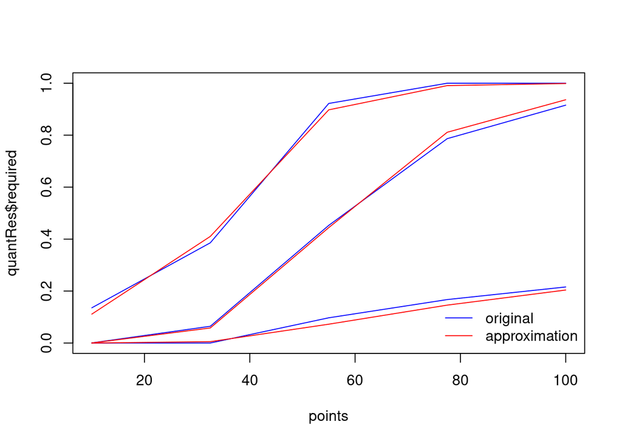

[output not shown]

[output cut: 12 more lines]

[output not shown]

```r
##' @param points optional parameter, which gives the dose values at which
##' the approximation should rely on (default: 5 values equally spaced from
##' minimum to maximum of the dose grid)
##' @param refDose the reference dose to be used (default: median of
##' \code{points})
##' @param logNormal use the log-normal prior? (not default) otherwise, the
##' normal prior for the logistic regression coefficients is used
##' @param verbose be verbose (progress statements and plot)? (default)
##'
##' @describeIn approximate Here the \dots argument can transport additional arguments for
##' \code{\link{Quantiles2LogisticNormal}}, e.g. in order to control the
##' approximation quality, etc.
##'
##' @example examples/Sample-methods-approximate.R
setMethod("approximate",
  signature =
    signature(object = "Samples", model = "LogisticLogNormalOrdinal"),
  def =
    function(object,
             model,
             data,
             points =
               seq(
                 from = min(data@doseGrid),
                 to = max(data@doseGrid),
                 length = 5L
               ),
             refDose = median(points),
             logNormal = FALSE,
             verbose = TRUE,
             grade,
             ...) {
      ## get the required quantiles at these dose levels:
      quants <- fit(object,
        model,
        data,
        points = points,
        quantiles = c(0.025, 0.975),
        middle = median,
        grade = grade
      )

      ## get better starting values if it is already a logistic normal
      ## model
      if (is(model, "LogisticNormal") && (!logNormal)) {
        means <- sapply(
          object@data,
          mean
        )
        cov <- cov(as.data.frame(object@data))

        parstart <- c(
          means[1], means[2],
          sqrt(cov[1, 1]), sqrt(cov[2, 2]),
          cov2cor(cov)[1, 2]
        )
      } else if (is(model, "LogisticLogNormal") && logNormal) {
        datTrafo <- with(
          object@data,
          cbind(
            alpha0,
            log(alpha1)
          )
        )

        means <- colMeans(datTrafo)
        cov <- cov(datTrafo)

        parstart <- c(
          means[1], means[2],
          sqrt(cov[1, 1]), sqrt(cov[2, 2]),
          cov2cor(cov)[1, 2]
        )
      } else {
        parstart <- NULL
      }

      ## run the approx function
      quantRes <- Quantiles2LogisticNormal(
        dosegrid = quants$dose,
        refDose = refDose,
        lower = quants$lower,
        upper = quants$upper,
        median = quants$middle,
        verbose = verbose,
        parstart = parstart,
        logNormal = logNormal,
        ...
      )

      if (verbose) {
        matplot(
          x = points,
          quantRes$required,
          type = "l", col = "blue", lty = 1
        )
        matlines(
          x = points,
          quantRes$quantiles,
          col = "red", lty = 1
        )
        legend("bottomright",
          legend = c("original", "approximation"),
          col = c("blue", "red"),
          lty = 1,
          bty = "n"
        )
      }

      ## return the model
      return(quantRes$model)
    }
)
approximate(samples, ordinal_model, ordinal_data, grade = 1L)
```

# 3 To do: Interaction with other `crmPack` classes

`DataOrdinal` and `LogisiticLogNormalOrdinal` objects need to interact with other `crmPack` classes such as `CohortSize`, `increments` and `NextBest` many of which make an implicit assumption that toxicity is dichotomous. With ordinal data, this is not the case. One could create ordinal variants of every such class. This is a significant amount of work. Pragmatically, I suggest a potentially simpler solution…

For each `crmPack` super-class (such as `CohortSize` and `Stopping`), define a wrapper ordinal-specific class with three slots: `grade`, `cumulative` and `rule`, where `rule` is one of the existing concrete classes. The wrapper class would extract the relevant `grade`-specific probabilities of toxicity from the supplied `Samples` object, create a pseudo `Samples` object of the equivalent binary probabilities and pass this pseudo object to the rule. `cumulative` would be a `flag` indicating whether or not the probabilities used would refer to the given `grade` alone or all `grade`s equal to or greater than the given `grade`. This allows all existing rules to be applied to the results of an ordinal CRM trial with minimum effort.

For example

```r
NextBestOrdinal(
  grade = 2,
  NextBestNCRM(target = c(0.2, 0.35), overdose = c(0.35, 1), max_over_dose_prob = 0.25),
  cumulative = FALSE
)
```

would apply a `NextBestNCRM` rule to the posterior probabilities of grade 2 toxicity.

# 4 References

[1] Agresti, A. (2010). Analysis of Ordinal Categorical Data. Hoboken, NJ: John Wiley & Sons.

[2] Agresti, A. (2013). Categorical Data Analysis. Hoboken, NJ: John Wiley & Sons.

[3] Agresti, A. (2015). Foundations of Linear and Generalized Linear Models. Hoboken, NJ: John Wiley & Sons.

[4] Albert, J. H. and Chib, S. (1993). Bayesian analysis of binary and polychotomous response data. Journal of the American Statistical Association, 88(422): 669–679.

[5] Albert, J. and Chib, S. (1997). Bayesian methods for cumulative, sequential and twostep ordinal data regression models. Technical report.

[6] Congdon, P. (2005). Bayesian Model for Categorical Data, Willey.

[7] Ishwaran, H. (2000). Univariate and Multirater Ordinal Cumulative Link Regression with Covariate SpecificCutpoints. The Canadian Journal of Statistics / La Revue Canadienne de Statistique, Vol. 28, No. 4 (Dec., 2000), pp. 715-730

[8] James, N. T., Harrell Jr, F. E., Shepherd, B. E. (2022) Bayesian Cumulative Probability Models for Continuous and Mixed Outcomes. arXiv:2102.00330v2 [stat.ME]

[9] Johnson, V. E. and Albert, J. H. (1999). Ordinal Data Modeling. Springer-Verlag, New York.

[10] McKinley, T. J., Morters, M., Wood, J. L. N. (2015) Bayesian Model Choice in Cumulative Link Ordinal Regression Models.

[11] McCullagh, P., and Nelder, J. A. (1989). Generalized Linear Models. 2nd ed. London: Chapman & Hall  
https://www.utstat.toronto.edu/~brunner/oldclass/2201s11/readings/glmbook.pdf

[12] Van Meter EM, Garrett-Mayer E, Bandyopadhyay D. Dose-finding clinical trial design for ordinal toxicity grades using the continuation ratio model: an extension of the continual reassessment method. Clin Trials. 2012 Jun;9(3):303-13. doi: 10.1177/1740774512443593. Epub 2012 Apr 30.  
https://www.ncbi.nlm.nih.gov/pmc/articles/PMC5531273/

[13] Wikipedia, https://en.wikipedia.org/wiki/Truncated_normal_distribution.

[14] Greene, William H. (2003). Econometric Analysis (5th ed.). Prentice Hall.

[15] Horrace, William C., “Some Results on the Multivariate Truncated Normal Distribution” (2005). Economics - Faculty Scholarship. 19.

[16] Jack Cartinhour (1990) One-dimensional marginal density functions of a truncated multivariate normal density function, Communications in Statistics - Theory and Methods, 19:1, 197-203, DOI: 10.1080/03610929008830197#